# Final assignment (summative)

Mao Li

2024-01-10

**Link to the Github repo: https://github.com/neo-258/MY472_Final_Assignment_Mao_Li/tree/master**

# 1. Introduction

This report addresses the research question: “Are there biases in who experiences stop and search by the UK police?” It seeks to investigate whether certain groups experience a disproportionately higher likelihood of being stopped and searched based on characteristics such as ethnicity, gender, and age. The analysis focuses on ethnic bias, utilizing the R to process stop and search data alongside population data broken down by area and ethnicity. Through the computation and visualization of stop and search rates and relative rates across different ethnic groups, the research seeks to elucidate potential disparities indicative of systemic bias.

# 2. Data

The analysis leverages two main datasets: population data and stop and search statistics.

Population data was obtained from the Home Office website, sourcing from the Office for National Statistics (ONS), which details ethnic compositions based on the 2021 Censuses.

Stop and search data were acquired from the UK Police Data website through the “Custom download” option, facilitating the extraction of the latest street-level stop and search information from December 2020 to November 2023. The data encompasses 43 territorial police force areas (PFAs) in England and Wales, including the British Transport Police. Rigorous data processing involved the exclusion of vehicle searches and integration of PFA and ethnicity columns, based on both self-defined and officer-observed ethnicity. The resulting dataset was stored in Google Cloud’s Bigquery.

Statistical analysis of stop and search numbers and overall rates per 1,000 population by ethnicity was conducted using SQL. Further, relative or disparity rates were computed by dividing the overall rates of ethnic minorities by those of whites. This process generated datasets comprising England and Wales as a whole, as well as various lower PFAs, serving as the foundation for the subsequent analysis.

# 3. Analysis

The analysis begins by examining the stop and search numbers, with Figure 1 showing that whites have the highest count, reflecting their majority in the population. However, to address the bias question, the focus shifts to the overall stop and search and relative rates, illuminating substantial disparities between ethnic minorities, especially blacks and whites.

**Figure 1: Numbers of stop and searches by ethnicity, England and Wales, 2020/2021 to 2022/2023**

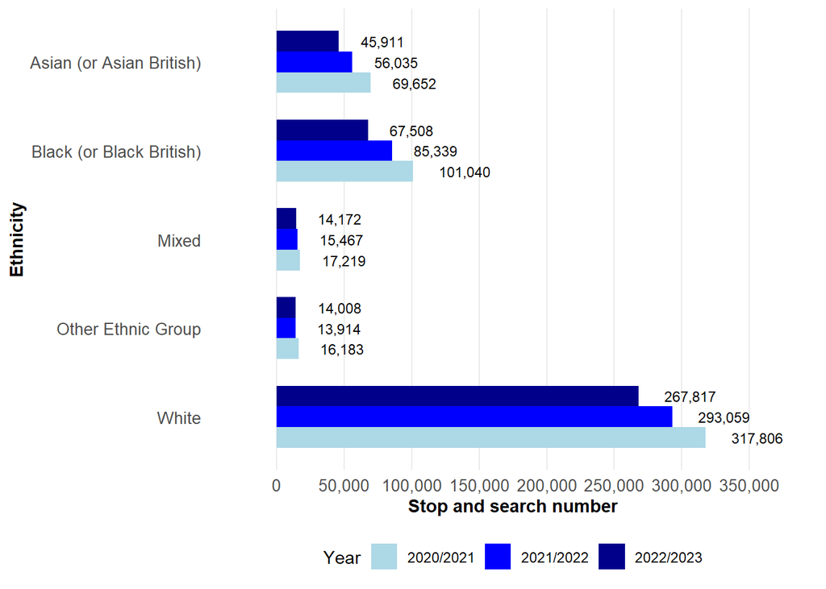

**Figure 2: Overall stop and search rates per 1,000 population by ethnicity, England and Wales, 2020/2021 to 2022/2023**

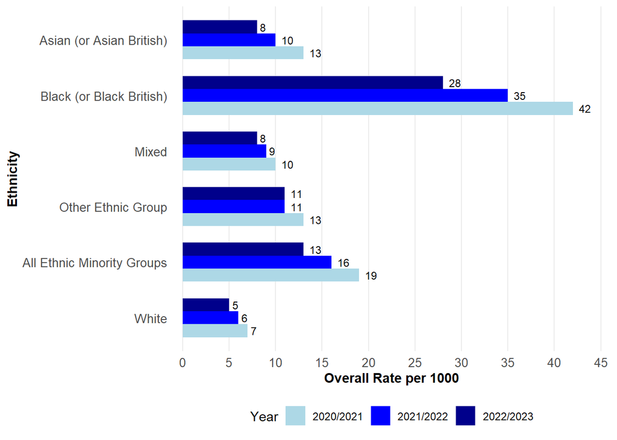

**Figure 3: Relative stop and search rates by ethnicity, England and Wales, 2020/2021 to 2022/2023**

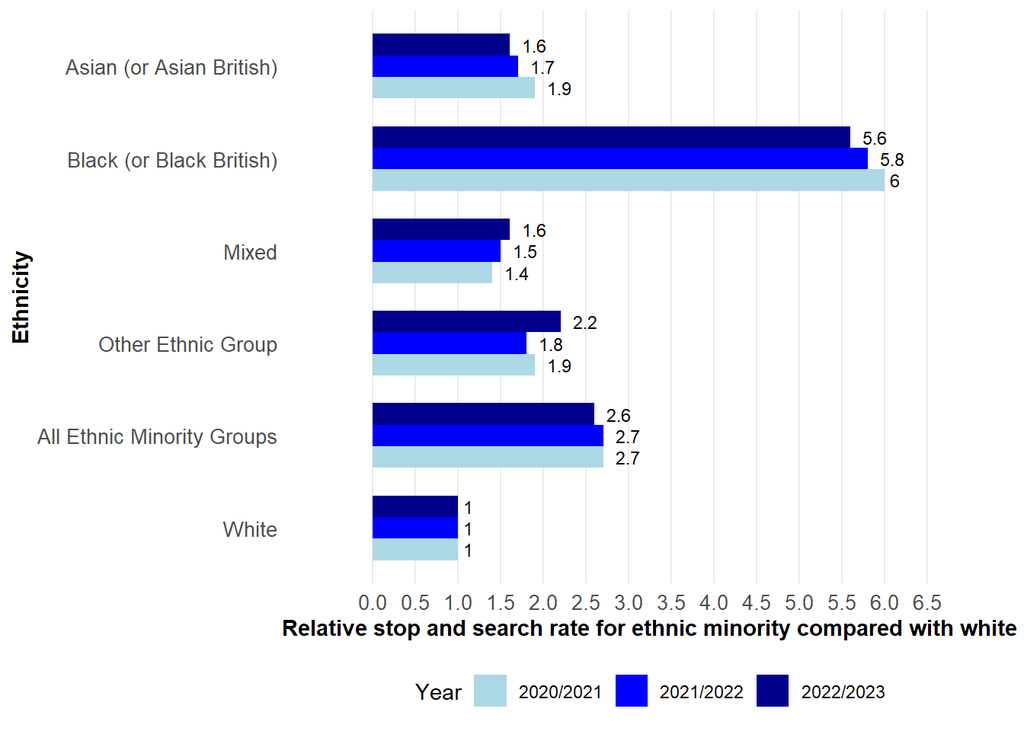

**Figure 4: Overall stop and search rates and relative rates for ethnic minorities, by Police Force Area, England and Wales, year ending November 2023**

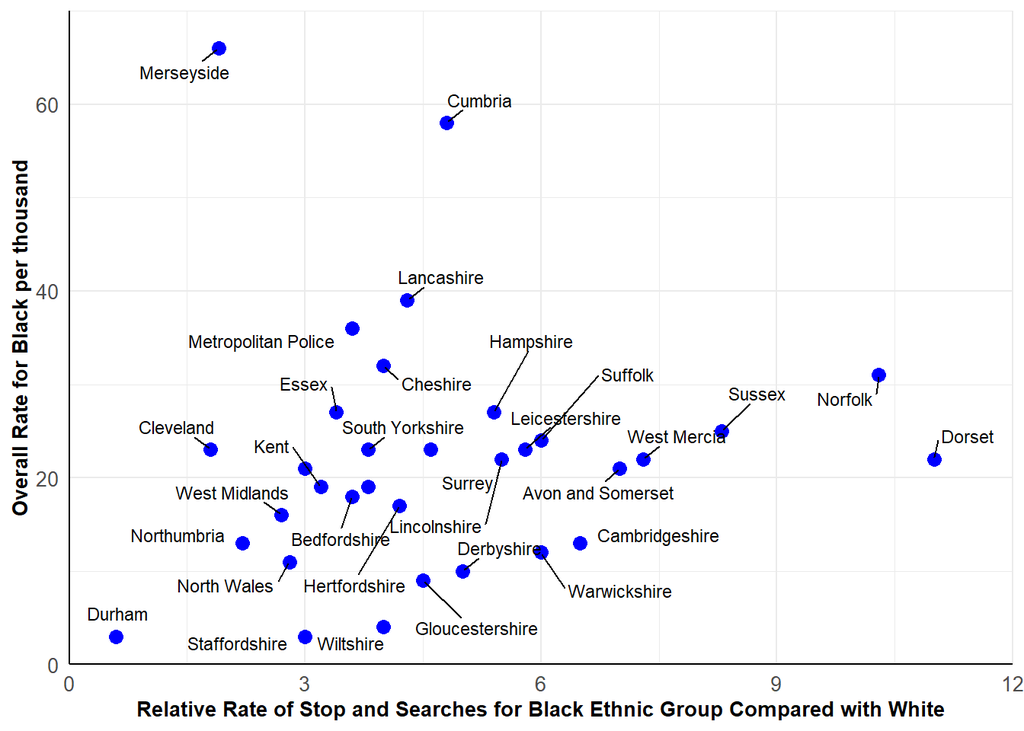

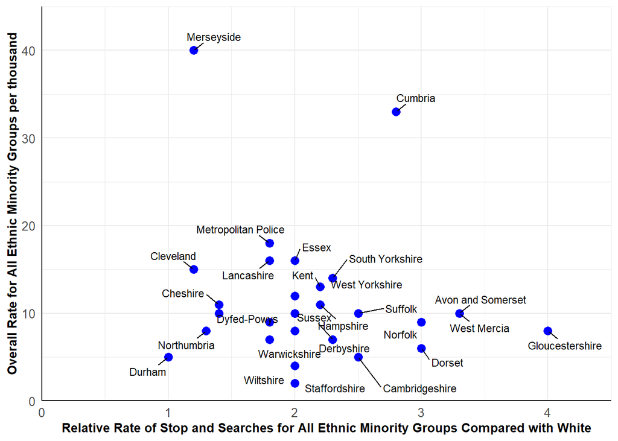

The interpretation of the bias question using stop and search rates based on population is subject to two dataset quality issues. First, population data relies on 2021 Census data, which is nearly three years old and may not account for changes in British demographics. Additionally, the population data is based on residential estimates and does not include the transient population like visitors, which may be recorded in search data. Second, concerns about stop and search data quality, such as underreporting or inaccuracies, and the inability of several police forces to provide data may impact the accuracy of the findings.

Lastly, the analysis acknowledges that the proportion of stop and search may not conclusively prove bias exists. For example, higher criminal rates in certain ethnic groups, suggesting a higher likelihood of criminal activity, can contribute to an increased probability of being searched, which shouldn’t be automatically indicative of ethnic bias.

## Reference:

UK Police (2023). data.police.uk. Available at: https://data.police.uk/ (Accessed: 09 January 2024).

Home Office (2023). Stop and search and arrests, year ending March 2023. Available at: https://www.gov.uk/government/statistics/stop-and-search-and-arrests-year-ending-march-2023 (Accessed: 09 January 2024).

Home Office (2023). Stop and search and arrests, year ending March 2023. Available at: https://www.ethnicity-facts-figures.service.gov.uk/crime-justice-and-the-law/policing/stop-and-search/latest/ (Accessed: 09 January 2024).

Home Office (2023). Update to stop and search and arrests statistics using 2021 Census estimates. Available at: https://www.gov.uk/government/statistics/update-to-stop-and-search-and-arrests-statistics-using-2021-census-estimates/update-to-stop-and-search-and-arrests-statistics-using-2021-census-estimates (Accessed: 09 January 2024).

Race Disparity Unit. Stop and search data and the effect of geographical differences. Available at: https://www.gov.uk/government/publications/stop-and-search-data-and-the-effect-of-geographical-differences/stop-and-search-interpreting-and-describing-statistics (Accessed: 09 January 2024).

# 4. Code Appendix

```r
# Suppress warning for the formatting of the output report
knitr::opts_chunk$set(echo = FALSE, warning = FALSE, message = FALSE)
# Install the required libraries if not installed
required_libraries <- c("bigrquery", "DBI", "readxl", "jsonlite", "dplyr", "readODS", "ggplot2", "ggrepel", "tidyverse", "scales")

for (lib in required_libraries) {
  if (!requireNamespace(lib, quietly = TRUE)) {
    install.packages(lib)
  }
}

# Load required packages
library(tidyverse)
library(bigrquery)
library(DBI)
library(readxl)
library(jsonlite)
library(dplyr)
library(readODS)
library(ggplot2)
library(ggrepel)
library(scales)
 # Running code for stop and search data collection, cleaning and storing can cost long time so it is set to not run.

# The latest stop and search CSV files from December 2020 to November 2023 have been downloaded from the link "https://data.police.uk/data/" and stored in local folder as "stop-and-search-data-dec20-nov23".
# Set the relative path to the data folder
stop_and_search_data_folder <- "Database/stop-and-search-data-dec20-nov23"

# List all subdirectories (months) in the data folder
months_from_dec20_nov23 <- list.dirs(path = stop_and_search_data_folder, full.names = FALSE, recursive = FALSE)

# Create an empty data frame to store aggregated data
stop_and_search_data <- data.frame()

# Loop through each month
for (month in months_from_dec20_nov23) {
  # List all CSV files in the current month's folder
  month_folder <- file.path(stop_and_search_data_folder, month)
  fls <- list.files(path = month_folder, pattern = ".csv", full.names = TRUE)

  # Loop through each CSV file
  for (f in fls) {
    message(f)

    # Extract police force id from the file path
    force_id <- sub(".*/[0-9]{4}-[0-9]{2}-(.*)-stop-and-search\\.csv", "\\1", f)
    message(force_id)

    # Read CSV file into memory with check.names = FALSE
    stop_and_search_file <- read.csv(f, stringsAsFactors = FALSE, check.names = FALSE)

    # Add "Police Force Area" column and assign the force_id
    stop_and_search_file$`Police force ID` <- force_id

    # Append data to the aggregate data frame
    stop_and_search_data <- rbind(stop_and_search_data, stop_and_search_file)
  }
}
# Delete rows where "Type" is Vehicle search because ethnicity information is not collected during these searches
stop_and_search_data <- stop_and_search_data[stop_and_search_data$Type != "Vehicle search", ]

# Define New Column "Ethnicity", based on a combination of self-defined ethnicity and officer-observed ethnicity (where self-defined ethnicity was not stated)
# Function to map ethnicity based on Self-defined and Officer-defined ethnicity
map_ethnicity <- function(self_defined, officer_defined) {

  # Obtain categories using function unique()
  # self_defined_ethnicity_categories <- unique(stop_and_search_data$`Self-defined ethnicity`)
  # officer_defined_ethnicity_categories <- unique(stop_and_search_data$`Officer-defined ethnicity`)

  # Ethnicity categories
  white_categories <- c("White - English/Welsh/Scottish/Northern Irish/British",
                        "White - Any other White background", "White - Irish",
                        "White - Gypsy or Irish Traveller")
  black_categories <- c("Black/African/Caribbean/Black British - African",
                        "Black/African/Caribbean/Black British - Caribbean",
                        "Black/African/Caribbean/Black British - Any other Black/African/Caribbean background")
  asian_categories <- c("Asian/Asian British - Pakistani", "Asian/Asian British - Indian",
                        "Asian/Asian British - Bangladeshi", "Asian/Asian British - Chinese",
                        "Asian/Asian British - Any other Asian background")
  mixed_categories <- c("Mixed/Multiple ethnic groups - White and Black African",
                        "Mixed/Multiple ethnic groups - White and Black Caribbean",
                        "Mixed/Multiple ethnic groups - Any other Mixed/Multiple ethnic background",
                        "Mixed/Multiple ethnic groups - White and Asian")
  other_categories <- c("Other ethnic group - Not stated", "Other ethnic group - Any other ethnic group",
                        "Other ethnic group - Arab")
  unknown_category <- "Not stated / Unknown"

  # Check if Self-defined ethnicity is not empty or NA or not stated
  if (!is.na(self_defined) && self_defined != "" && self_defined != "Other ethnic group - Not stated") {
    if (self_defined %in% white_categories) {
      return("White")
    } else if (self_defined %in% black_categories) {
      return("Black (or Black British)")
    } else if (self_defined %in% asian_categories) {
      return("Asian (or Asian British)")
    } else if (self_defined %in% mixed_categories) {
      return("Mixed")
    } else if (self_defined %in% other_categories) {
      return("Other Ethnic Group")
    } else {
      return(unknown_category)
    }
  } else {
    # If Self-defined ethnicity is empty or not stated, use Officer-defined ethnicity instead
    # or consider it as "Not stated / Unknown"
    if (is.na(officer_defined) || officer_defined == "") {
      return(unknown_category)
    } else if (officer_defined == "White") {
      return("White")
    } else if (officer_defined == "Black") {
      return("Black (or Black British)")
    } else if (officer_defined == "Asian") {
      return("Asian (or Asian British)")
    } else if (officer_defined == "Mixed") {
      return("Mixed")
    } else if (officer_defined == "Other") {
      return("Other Ethnic Group")
    } else {
      return(unknown_category)
    }
  }
}

# Apply the mapping function to create the "Ethnicity" column
stop_and_search_data$Ethnicity <- mapply(map_ethnicity, stop_and_search_data$`Self-defined ethnicity`, stop_and_search_data$`Officer-defined ethnicity`)
# A relational database was created in the cloud to store a variety of different but related tables using package Bigquery.
project_name <- "my472-final-database-409622"
billing_id <- "my472-final-database-409622"
dataset_name <- "UK_Police_Bias_Analysis"
# Access to the cloud dataset
db <- dbConnect(
  bigrquery::bigquery(),
  project = project_name,
  dataset = dataset_name,
  billing = billing_id
)
```

```r
# Write stop and search data into cloud database, which may have to take several minutes due to the data size
dbWriteTable(db, "stop_and_search", stop_and_search_data, overwrite = TRUE)

# Close the connection
dbDisconnect(db)
# Through Home Office website
# (https://www.gov.uk/government/statistics/stop-and-search-and-arrests-year-ending-march-2023),  the ODS file providing population data was  downloaded and stored in the local folder as "stop-search-data-tables-summary-mar23.ods".

# Specify the path to the ODS file
population_file_path <- "Database/stop-search-data-tables-summary-mar23.ods"

# Read the population ODS file
population_data <- read_ods(path = population_file_path, sheet = "P_1", skip=3, .name_repair = "minimal")

# Filter out rows with Census Year 2011
population_data <- population_data[population_data$Census.Year == 2021, ]

# Modify the column names
colnames(population_data) <- c("Census_Year", "Geocode", "Police_Force_Area",
                               "Self_defined_ethnicity", "Population")

# Loop through each ethnic category and replace in the column
original_ethnicity_categories <- c("Asian or Asian British", "Black or Black British", "Mixed", "Other Ethnic Group", "White")

new_ethnicity_categories <- c("Asian (or Asian British)", "Black (or Black British)", "Mixed", "Other Ethnic Group", "White")

for (i in seq_along(original_ethnicity_categories)) {
  population_data$Self_defined_ethnicity[population_data$Self_defined_ethnicity == original_ethnicity_categories[i]] <- new_ethnicity_categories[i]
}

# Initialize an empty data frame to store the aggregated data
aggregate_population <- data.frame(
  Census_Year = 2021,
  Geocode = "K04000001",
  Police_Force_Area = "England and Wales",
  Self_defined_ethnicity = new_ethnicity_categories,
  Population = numeric(length(new_ethnicity_categories)),
  check.names = FALSE
)

# Loop through ethnicity categories and calculate the sum for each
for (category in new_ethnicity_categories) {
  population_sum <- sum(population_data$Population[population_data$Self_defined_ethnicity == category])
  aggregate_population[aggregate_population$Self_defined_ethnicity == category, "Population"] <- population_sum
}
# API for a list of all the police forces available except the British Transport Policeand
pfa_api <- "https://data.police.uk/api/forces"
pfa_data <- fromJSON(pfa_api)

# Add British Transport Police to the data frame
btp_data <- data.frame(id = "btp", name = "British Transport Police")
pfa_data <- rbind(pfa_data, btp_data)

# Obtain the categories in stop_and_search_number_pfa_2023 and population_data
# unique(population_data$`Police Force Area`)
# unique(pfa_data$name)

# Create a mapping between the pfa categories
mapping <- c(
  "Avon and Somerset Constabulary" = "Avon and Somerset",
  "British Transport Police" = "British Transport Police",
  "Bedfordshire Police" = "Bedfordshire",
  "Cambridgeshire Constabulary" = "Cambridgeshire",
  "Cheshire Constabulary" = "Cheshire",
  "City of London Police" = "London, City of",
  "Cleveland Police" = "Cleveland",
  "Cumbria Constabulary" = "Cumbria",
  "Derbyshire Constabulary" = "Derbyshire",
  "Devon & Cornwall Police" = "Devon and Cornwall",
  "Dorset Police" = "Dorset",
  "Durham Constabulary" = "Durham",
  "Dyfed-Powys Police" = "Dyfed-Powys",
  "Essex Police" = "Essex",
  "Gloucestershire Constabulary" = "Gloucestershire",
  "Greater Manchester Police" = "Greater Manchester",
  "Gwent Police" = "Gwent",
  "Hampshire Constabulary" = "Hampshire",
  "Hertfordshire Constabulary" = "Hertfordshire",
  "Humberside Police" = "Humberside",
  "Kent Police" = "Kent",
  "Lancashire Constabulary" = "Lancashire",
  "Leicestershire Police" = "Leicestershire",
  "Lincolnshire Police" = "Lincolnshire",
  "Merseyside Police" = "Merseyside",
  "Metropolitan Police Service" = "Metropolitan Police",
  "Norfolk Constabulary" = "Norfolk",
  "North Wales Police" = "North Wales",
  "North Yorkshire Police" = "North Yorkshire",
  "Northamptonshire Police" = "Northamptonshire",
  "Northumbria Police" = "Northumbria",
  "Nottinghamshire Police" = "Nottinghamshire",
  "Police Service of Northern Ireland" = "Northern Ireland",
  "South Wales Police" = "South Wales",
  "South Yorkshire Police" = "South Yorkshire",
  "Staffordshire Police" = "Staffordshire",
  "Suffolk Constabulary" = "Suffolk",
  "Surrey Police" = "Surrey",
  "Sussex Police" = "Sussex",
  "Thames Valley Police" = "Thames Valley",
  "Warwickshire Police" = "Warwickshire",
  "West Mercia Police" = "West Mercia",
  "West Midlands Police" = "West Midlands",
  "West Yorkshire Police" = "West Yorkshire",
  "Wiltshire Police" = "Wiltshire"
)

# Map PFA names using the created mapping
pfa_data$name <- sapply(pfa_data$name, function(pfa) {
  mapped_pfa <- mapping[pfa]
  if (is.null(mapped_pfa)) {
    warning(paste("No mapping found for", pfa))
    return(pfa)
  } else {
    return(mapped_pfa)
  }
})

# Access to the cloud dataset
db <- dbConnect(
  bigrquery::bigquery(),
  project = project_name,
  dataset = dataset_name,
  billing = billing_id
)

# Write the data to the cloud database
dbWriteTable(db, "police_force_area", pfa_data, overwrite = TRUE)

# Close the connection
dbDisconnect(db)
# Define a function to retrieve the aggregate stop and search numbers for each year, Police Force Area, and ethnicity
number_query <- function(start_date, end_date, year) {
  query <- paste0("
    SELECT
      '", year, "' AS Year,
      pfa.name AS Police_Force_Area,
      s.Ethnicity,
      COUNT(*) AS Stop_and_search_number
    FROM
      stop_and_search s
    JOIN
      police_force_area pfa ON s.`Police force ID` = pfa.id
    WHERE
      DATE(s.Date) BETWEEN '", start_date, "' AND '", end_date, "'
    GROUP BY
      Year, pfa.name, s.Ethnicity
    ORDER BY
      Year, pfa.name, s.Ethnicity
  ")

  result <- dbGetQuery(db, query)
  return(result)
}

# Access to the cloud dataset
db <- dbConnect(
  bigrquery::bigquery(),
  project = project_name,
  dataset = dataset_name,
  billing = billing_id
)
```

```r
# Run the function for each table
stop_and_search_number_pfa_2021 <- number_query("2020-12-01", "2021-11-30", "2020/2021")
stop_and_search_number_pfa_2022 <- number_query("2021-12-01", "2022-11-30", "2021/2022")
stop_and_search_number_pfa_2023 <- number_query("2022-12-01", "2023-11-30", "2022/2023")

# Exclude rows where Ethnicity is "Not stated / Unknown"
stop_and_search_number_pfa_2021 <- stop_and_search_number_pfa_2021[stop_and_search_number_pfa_2021$Ethnicity != "Not stated / Unknown", ]
stop_and_search_number_pfa_2022 <- stop_and_search_number_pfa_2022[stop_and_search_number_pfa_2022$Ethnicity != "Not stated / Unknown", ]
stop_and_search_number_pfa_2023 <- stop_and_search_number_pfa_2023[stop_and_search_number_pfa_2023$Ethnicity != "Not stated / Unknown", ]

# Write the data to the cloud database
dbWriteTable(db, "stop_and_search_number_pfa_2021", stop_and_search_number_pfa_2021, overwrite = TRUE)
dbWriteTable(db, "stop_and_search_number_pfa_2022", stop_and_search_number_pfa_2022, overwrite = TRUE)
dbWriteTable(db, "stop_and_search_number_pfa_2023", stop_and_search_number_pfa_2023, overwrite = TRUE)

# Close the connection
dbDisconnect(db)
# Function to run the query and get the results
aggregate_number_query <- function(table_name, year) {
  query <- paste0("
    SELECT
      '", year, "' AS Year,
      'England and Wales' AS Police_Force_Area,
      Ethnicity,
      SUM(Stop_and_search_number) AS Stop_and_search_number
    FROM
      ", table_name, "
    GROUP BY
      Year, Police_Force_Area, Ethnicity
    ORDER BY
      Year, Ethnicity
  ")

  result <- dbGetQuery(db, query)
  return(result)
}

# Access to the cloud dataset
db <- dbConnect(
  bigrquery::bigquery(),
  project = project_name,
  dataset = dataset_name,
  billing = billing_id
)

# Run the function for each table
aggregate_number_2021 <- aggregate_number_query("stop_and_search_number_pfa_2021", "2020/2021")
aggregate_number_2022 <- aggregate_number_query("stop_and_search_number_pfa_2022", "2021/2022")
aggregate_number_2023 <- aggregate_number_query("stop_and_search_number_pfa_2023", "2022/2023")

aggregate_stop_and_search_number <- rbind(
  aggregate_number_2021,
  aggregate_number_2022,
  aggregate_number_2023
  )

# Close the connection
dbDisconnect(db)
# Define custom order for Ethnicity levels
aggregate_number_custom_order <- c("White",
                                    "All Ethnic Minority Groups",
                                    "Other Ethnic Group",
                                    "Mixed",
                                    "Black (or Black British)",
                                    "Asian (or Asian British)"
)

# Apply custom order to the Ethnicity column
aggregate_stop_and_search_number$Ethnicity <- factor(aggregate_stop_and_search_number$Ethnicity, levels = aggregate_number_custom_order)

# Create a bar chart
chart_aggregate_number <- ggplot(aggregate_stop_and_search_number, aes(x = as.numeric(Stop_and_search_number), y = Ethnicity, fill = Year)) +
  geom_col(position = "dodge", width = 0.7) +
  geom_text(aes(label = comma(as.numeric(Stop_and_search_number))), position = position_dodge(width = 0.7), vjust = 0.5, hjust = -0.5, size = 3) +
  scale_fill_manual(values = c("lightblue", "blue", "darkblue")) +
  theme_minimal() +  # Use a minimal theme
  theme(
    legend.position = "bottom",
    legend.direction = "horizontal",
    legend.box = "horizontal",
    panel.grid.major.y = element_blank(),
    panel.grid.minor.y = element_blank(),
    panel.grid.minor.x = element_blank(),  # Remove gridlines
    axis.title.x = element_text(face = "bold"),  # Make x-axis title bold
    axis.title.y = element_text(face = "bold"),  # Make y-axis title bold
    axis.text.x = element_text(size = 10),  # Adjust x-axis label size
    axis.text.y = element_text(size = 10)
  ) +
  labs(x = "Stop and search number", y = "Ethnicity") +
  scale_x_continuous(limits = c(0, 350000), breaks = seq(0, 350000, by = 50000), expand = c(0, 50000), labels = comma)

# Print the chart
print(chart_aggregate_number)
# Function to calculate overall rates
calculate_overall_rate <- function(stop_and_search_number, population) {
  # Overall rates are rounded to the integer digits using the round-half-away-from-zero method.
  overall_rate <- round(sum(stop_and_search_number) / sum(population) * 1000)
  return(overall_rate)
}

# Create vectors to store results
years <- unique(aggregate_stop_and_search_number$Year)
ethnicities <- unique(aggregate_stop_and_search_number$Ethnicity)

# Initialize data frame to store results
overall_rate_df <- data.frame(Year = character(), Police_Force_Area = character(), Ethnicity = character(), Overall_rate_per_1000 = numeric())

# Define ethnic minority categories
ethnic_minority_categories <- c("Asian (or Asian British)", "Black (or Black British)", "Mixed", "Other Ethnic Group")

# Loop through each year and ethnicity
for (year in years) {
  minorities_num <- 0
  minorities_pop <- 0

  for (ethnicity in ethnicities) {
    # Extract stop search number
    stop_search <- aggregate_stop_and_search_number$Stop_and_search_number[aggregate_stop_and_search_number$Year == year & aggregate_stop_and_search_number$Ethnicity == ethnicity]

    # Extract population number
    population <- aggregate_population$Population[aggregate_population$Self_defined_ethnicity == ethnicity]

    # Calculate rate
    rate <- calculate_overall_rate(stop_search, population)

    # Append to result dataframe
    overall_rate_df <- rbind(overall_rate_df, data.frame(Year = year, Police_Force_Area = "England and Wales", Ethnicity = ethnicity, Overall_rate_per_1000 = rate))

    if (ethnicity %in% ethnic_minority_categories) {
      minorities_num <- minorities_num + stop_search
      minorities_pop <- minorities_pop + population
    }
  }

  # Calculate All Ethnic Minority Groups rate
  all_minority_rate <- calculate_overall_rate(minorities_num, minorities_pop)

  overall_rate_df <- rbind(overall_rate_df, data.frame(Year = year, Police_Force_Area = "England and Wales", Ethnicity = "All Ethnic Minority Groups", Overall_rate_per_1000 = all_minority_rate))
}
# Define the custom order for Ethnicity
overall_rate_custom_order <- c("White",
                               "All Ethnic Minority Groups",
                               "Other Ethnic Group",
                               "Mixed",
                               "Black (or Black British)",
                               "Asian (or Asian British)"
                               )
```

```r
# Set the factor levels for Ethnicity based on the custom order
overall_rate_df$Ethnicity <- factor(overall_rate_df$Ethnicity, levels = overall_rate_custom_order)

# Create a bar plot for overall rates
chart_overall_rate <- ggplot(overall_rate_df, aes(x = as.numeric(Overall_rate_per_1000), y = Ethnicity, fill = Year)) +
  geom_col(position = "dodge", width = 0.7) +  # Bar plot
  geom_text(aes(label = as.numeric(Overall_rate_per_1000)), position = position_dodge(width = 0.7), vjust = 0.5, hjust= -0.5, size = 3) +  # Add text labels
  scale_fill_manual(values = c("lightblue", "blue", "darkblue")) +  # Custom fill colors
  theme_minimal() +  # Use a minimal theme
  theme(
    legend.position = "bottom", legend.direction = "horizontal", legend.box = "horizontal",
    panel.grid.major.y = element_blank(), panel.grid.minor.y = element_blank(), panel.grid.minor.x = element_blank(),  # Remove gridlines
    axis.title.x = element_text(face = "bold"),  # Make x-axis title bold
    axis.title.y = element_text(face = "bold"),  # Make y-axis title bold
    axis.text.x = element_text(size = 10),  # Adjust x-axis label size
    axis.text.y = element_text(size = 10)  # Adjust y-axis label size
  ) +
  labs(x = "Overall Rate per 1000", y = "Ethnicity") +  # Axis labels
  scale_x_continuous(limits = c(0, 45), breaks = seq(0, 45, by = 5), expand = c(0, 1))  # X-axis settings

# Print the plot
print(chart_overall_rate)
# Initialize an empty data frame to store the results
relative_rate_df <- data.frame()

# Get unique years and ethnicities
years <- unique(overall_rate_df$Year)
ethnicities <- unique(overall_rate_df$Ethnicity)

all_ethnicity_categories <- c("Asian (or Asian British)", "Black (or Black British)", "Mixed", "Other Ethnic Group","All Ethnic Minority Groups", "White")

# Nested loops to calculate relative rates
for (year in years) {
  # Filter overall rate for the current year and white
  white_rate <- overall_rate_df %>%
    filter(Year == year, Ethnicity == "White")

  for (ethnicity in ethnicities) {

    # Check if the ethnicity is in the specified categories
    if (ethnicity %in% all_ethnicity_categories) {

      # Filter data for the current year and ethnicity
      minority_data <- overall_rate_df %>%
        filter(Year == year, Ethnicity == ethnicity)

      # Calculate the Overall_rate_per_1000 for White
      white_rate <- overall_rate_df %>%
        filter(Year == year, Ethnicity == "White") %>%
        select(Police_Force_Area, Overall_rate_per_1000) %>%
        rename(White_rate = Overall_rate_per_1000)

      # Calculate Relative rate
      relative_rate <- minority_data %>%
        left_join(white_rate, by = "Police_Force_Area") %>%
        # relative rates are rounded to the tenth place using the round-half-away-from-zero method.
        mutate(Relative_rate = round(Overall_rate_per_1000 / White_rate, 1) ) %>%
        select(Year, Police_Force_Area, Ethnicity, Relative_rate)

      # Append the result to the final data frame
      relative_rate_df <- bind_rows(relative_rate_df, relative_rate)
    }
  }
}
# Bar Chart for relative stop and search rates
# Specify the desired order for the "Ethnicity" variable in the chart
relative_rate_custom_order <- c("White",
                                "All Ethnic Minority Groups",
                                "Other Ethnic Group",
                                "Mixed",
                                "Black (or Black British)",
                                "Asian (or Asian British)"
)

relative_rate_df$Ethnicity <- factor(relative_rate_df$Ethnicity, levels = relative_rate_custom_order)

chart_relative_rate <-
  ggplot(relative_rate_df, aes(x = as.numeric(Relative_rate), y = Ethnicity, fill = Year)) +
  geom_col(position = "dodge", width = 0.7) +
  geom_text(aes(label = as.numeric(Relative_rate)), position = position_dodge(width = 0.7), vjust = 0.5, hjust= -0.5, size = 3) +  # Add text labels
  scale_fill_manual(values = c("lightblue", "blue", "darkblue")) +
  theme_minimal() +
  theme(legend.position = "bottom", legend.direction = "horizontal", legend.box = "horizontal",
        panel.grid.major.y = element_blank(), panel.grid.minor.y = element_blank(), panel.grid.minor.x = element_blank(),
        axis.title.x = element_text(face = "bold"),  # Make x-axis title bold
        axis.title.y = element_text(face = "bold"),  # Make y-axis title bold
        axis.text.x = element_text(size = 10),  # Adjust x-axis label size
        axis.text.y = element_text(size = 10)  # Adjust y-axis label size
  ) +
  labs(x = "Relative stop and search rate for ethnic minority compared with white", y = "Ethnicity") +
  scale_x_continuous(limits = c(0, 6.5), breaks = seq(0, 6.5, by = 0.5), expand = c(0, 1))

print(chart_relative_rate)
# Initialize an empty data frame to store the results
overall_rate_pfa_2023 <- data.frame(
  Year = character(),
  Police_Force_Area = character(),
  Ethnicity = character(),
  Overall_rate_per_1000 = numeric()
)

# Get unique Police_Force_Area and Ethnicity values
pfas <- unique(stop_and_search_number_pfa_2023$Police_Force_Area)
ethnicities <- unique(stop_and_search_number_pfa_2023$Ethnicity)

# Nested loops to calculate overall rates
for (pfa in pfas) {
  minorities_num_pfa <- 0
  minorities_pop_pfa <- 0

  for (ethnicity in ethnicities) {
    # Filter data from stop_and_search_number_pfa_2023
    stop_search_data <- stop_and_search_number_pfa_2023 %>%
      filter(Police_Force_Area == pfa, Ethnicity == ethnicity)

    # Filter data from population_data
    population_data_subset <- population_data %>%
      filter(Police_Force_Area == pfa, Self_defined_ethnicity == ethnicity)

    # Check if data is available for both stop_and_search and population
    if (nrow(stop_search_data) > 0 && nrow(population_data_subset) > 0) {

      # Calculate overall rate
      overall_rate_value <- calculate_overall_rate(
        stop_search_data$Stop_and_search_number,
        population_data_subset$Population
      )

      # Create a data frame with the result
      result_df <- data.frame(
        Year = "2022/2023",
        Police_Force_Area = pfa,
        Ethnicity = ethnicity,
        Overall_rate_per_1000 = overall_rate_value
      )
```

```r
      # Append the result to the overall_rate_pfa_2023 data frame
      overall_rate_pfa_2023 <- bind_rows(overall_rate_pfa_2023, result_df)

      if (ethnicity %in% ethnic_minority_categories) {
        minorities_num_pfa <- minorities_num_pfa + stop_search_data$Stop_and_search_number
        minorities_pop_pfa <- minorities_pop_pfa + population_data_subset$Population
      }
    }
  }
  # Calculate All Ethnic Minority Groups rate for an area
  all_minority_rate <- calculate_overall_rate(minorities_num_pfa, minorities_pop_pfa)

  overall_rate_pfa_2023 <- bind_rows(
    overall_rate_pfa_2023,
    data.frame(
      Year = "2022/2023",
      Police_Force_Area = pfa,
      Ethnicity = "All Ethnic Minority Groups",
      Overall_rate_per_1000 = all_minority_rate
    )
  )
}

# Exclude rows where Police Force Area is "British Transport Police" and "London, City of",
# because the small resident population and large transient population in City of London means that rates can be misleading.
# However, they still have been included in the England and Wales total when calculating overall and relative rates.
overall_rate_pfa_2023 <- overall_rate_pfa_2023[overall_rate_pfa_2023$Police_Force_Area != "British Transport Police", ]
overall_rate_pfa_2023 <- overall_rate_pfa_2023[overall_rate_pfa_2023$Police_Force_Area != "London, City of", ]

# Initialize an empty data frame to store the results
relative_rate_pfa_2023 <- data.frame(
  Year = character(),
  Police_Force_Area = character(),
  Ethnicity = character(),
  Relative_rate = numeric()
)

# Get unique years and ethnicities excluding "White"
pfas <- unique(overall_rate_pfa_2023$Police_Force_Area)
ethnicities_no_white <- setdiff(unique(overall_rate_pfa_2023$Ethnicity), "White")

# Nested loops to calculate relative rates
for (pfa in pfas) {

  # Filter overall rate for "White" from overall_rate_pfa_2023
  white_overall_rate <- overall_rate_pfa_2023 %>%
    filter(Police_Force_Area == pfa, Ethnicity == "White")

  for (ethnicity in ethnicities_no_white) {

    # Filter overall rate for the current ethnicity from overall_rate_pfa_2023
    overall_rate <- overall_rate_pfa_2023 %>%
      filter(Police_Force_Area == pfa, Ethnicity == ethnicity)

    # Check if data is available for both "White" and the current ethnicity
    if (nrow(white_overall_rate) > 0 && nrow(overall_rate) > 0) {

      # Calculate relative rate
      relative_rate_value <- round(
        overall_rate$Overall_rate_per_1000 / white_overall_rate$Overall_rate_per_1000,
        1
      )

      # Create a data frame with the result
      result_df <- data.frame(
        Year = "2022/2023",
        Police_Force_Area = pfa,
        Ethnicity = ethnicity,
        Relative_rate = relative_rate_value
      )

      # Append the result to the relative_rate_pfa_2023 data frame
      relative_rate_pfa_2023 <- bind_rows(relative_rate_pfa_2023, result_df)
    }
  }
}
# Filter data for the specific ethnicity
overall_ethnicity_data_black <- overall_rate_pfa_2023 %>%
  filter(Ethnicity == "Black (or Black British)")

relative_ethnicity_data_black <- relative_rate_pfa_2023 %>%
  filter(Ethnicity == "Black (or Black British)")

# Create scatter plot
plot_black <- ggplot(data = relative_ethnicity_data_black, aes(x = Relative_rate, y = overall_ethnicity_data_black$Overall_rate_per_1000)) +
  geom_point(color = "blue", size = 3) +
  geom_text_repel(aes(label = Police_Force_Area), size = 3, color = "black", box.padding = 0.5, max.overlaps = 12) +
  theme_minimal() +
  scale_x_continuous(limits = c(0, 12), expand = c(0, 0), name = "Relative Rate of Stop and Searches for Black Ethnic Group Compared with White") +
  scale_y_continuous(limits = c(0, 70), expand = c(0, 0), name = "Overall Rate for Black per thousand") +
  theme(
    axis.text = element_text(size = 10, face = "plain"),
    axis.title = element_text(size = 10, face = "bold"),
    axis.line = element_line(color = "black", size = 0.5, linetype = "solid")) +
  labs(x = NULL, y = NULL)

# Filter data for the specific ethnicity
overall_ethnicity_data_all_other <- overall_rate_pfa_2023 %>%
  filter(Ethnicity == "All Ethnic Minority Groups")

relative_ethnicity_data_all_other <- relative_rate_pfa_2023 %>%
  filter(Ethnicity == "All Ethnic Minority Groups")

# Create scatter plot
plot_all_other <- ggplot(data = relative_ethnicity_data_all_other, aes(x = Relative_rate, y = overall_ethnicity_data_all_other$Overall_rate_per_1000)) +
  geom_point(color = "blue", size = 3) +
  geom_text_repel(aes(label = Police_Force_Area), size = 3, color = "black", box.padding = 0.5, max.overlaps = 10) +
  theme_minimal() +
  scale_x_continuous(limits = c(0, 4.5), expand = c(0, 0), name = "Relative Rate of Stop and Searches for All Ethnic Minority Groups Compared with White") +
  scale_y_continuous(limits = c(0, 45), expand = c(0, 0), name = "Overall Rate for All Ethnic Minority Groups per thousand") +
  theme(
    axis.text = element_text(size = 10, face = "plain"),
    axis.title = element_text(size = 10, face = "bold"),
    axis.line = element_line(color = "black", size = 0.5, linetype = "solid")) +
  labs(x = NULL, y = NULL)

print(plot_black)
print(plot_all_other)
# this chunk generates the complete code appendix.
```